# Lab 04, Experiment 2

```python
%matplotlib inline
```

# PAM Analysis with Eye Diagrams

# To generate a PAM signal and then display its eye diagram

```python
#%%writefile showfun.py
# File: showfun.py
# "show" functions like showft, showpsd, etc
from pylab import *
def showft(tt, xt, ff_lim):
    """
    Plot (DFT/FFT approximation to) Fourier transform of x(t)
    Displays magnitude |X(f)| either linear and absolute or
    normalized (wrt to maximum value) in dB. Phase of X(f) is
        shown in degrees.
        >>>>> showft(tt, xt, ff_lim) <<<<<
        where tt:time axis (increments Ts=1/Fs) for x(t)
            xt:sampled CT signal x(t))
            ff_lim = [f1,f2,llim]
            f1:lower frequency limit for display
            f2:upper frequency limit for display
            llim = 0: display |X(f)| linear and absolute
            llim > 0: same as llim = 0 but phase is masked
                      (set to zero) for |X(f)| < llim
            llim < 0: display 20*log_{10}(|X(f)|/max(|X(f)|))
                      in dB with lower display limit llim dB,
                      phase is masked (set to zero) for f
                      with magnitude (dB, normalized) < llim
        """
    # ***** Prepare x(t), swap pos/neg parts of time axis *****
    n = len(tt)
    fs = int((n-1)/float(tt[-1]-tt[0])) 	# Sampling rate
    ixp = where(tt>=0)[0]			# Indexes for t>=0
    ixn = where(tt<0)[0]			# Indexes for t<0
    tlen = tt[-1]
    xt = hstack((xt[ixp],xt[ixn])) 		# Swap pos/neg time axis parts
    llim = ff_lim[2]
    f11, f12 = ff_lim[0], ff_lim[1]


    # ***** Compute X(f), make frequency axis *****
    Xf = fft(xt)/float(fs)			# DFT/FFT of x(t),

    # scaled for X(f) approximation
    ff = fs*arange(n)/float(n) 		# Frequency axisi
    if ff_lim[0] < 0:
    	ixp = where(ff < fs/2)[0]
    	ixn = where(ff >= fs/2)[0]
    	ff = hstack((ff[ixn]-fs,ff[ixp]))
    	Xf = hstack((Xf[ixn],Xf[ixp]))

    # ***** Compute |X(f)|, arg[X(f)] *****
    absXf = abs(Xf)				# Magnitude |X(f)|
    argXf = angle(Xf)			# Phase arg[X(f)]

    if llim < 0:
    	absXf = 20*log10((absXf)/max(absXf))
    	ix = where(absXf < ff_lim[2])[0]
    	argXf[ix] = zeros(len(ix))
    	absXf[ix] = -60*ones(len(ix))
    else:
    	ix = where(absXf < ff_lim[2])[0]
    	argXf[ix]=zeros(len(ix))

    ix = where(logical_and(ff>= ff_lim[0], ff < ff_lim[1]))[0]
    ff = ff[ix]
    absXf=absXf[ix]
    argXf=argXf[ix]

    # ***** Plot magnitude/phase *****
    f1 = figure()
    af11 = f1.add_subplot(211)
    af11.plot(ff,absXf)
    af11.grid()
    if llim >= 0:
    	af11.set_ylabel('|X(f)|')
    else:
    	af11.set_ylabel('|X(f)| in dB')
    strgt = 'FT Approximation, $F_s=$' + str(fs) + ' Hz'
    strgt = strgt + ', N=' + str(n)
    strgt = strgt + ', $\Delta_f$={0:3.2f}'.format(fs/float(n)) + ' Hz'
    af11.set_title(strgt)
    af12 = f1.add_subplot(212)
    af12.plot(ff,180/pi*argXf) 		# Plot phase in degrees
    af12.grid()
    af12.set_ylabel('arg[X(f)] [deg]')
    af12.set_xlabel('f [Hz]')
    show()



def showeye(rt, Fs, FB, NTd=50, dispparms=[]):
    """
    Display eye diagram of digital PAM signal r(t)
    >>>>> showeye(rt, Fs, FB, NTd, dispparms) <<<<<
    where rt: received PAM signal r(t)=sum_n a_n*q(t-nTB)
    Fs: sampling rate for r(t)
    FB: Baud rate of DT sequence a_n, TB = 1/FB
    NTd: Number of traces displayed
    dispparms = [delay, width, ylim1, ylim2]
    delay: trigger delay (in TB units, e.g., 0.5)
    width: display width (in TB units, e.g., 3)
    ylim1: lower display limit, vertical axis
    ylim2: upper display limit, vertical axis
    """
    t0 = dispparms[0]/float(FB)         # Delay in sec
    tw = dispparms[1]/float(FB)         # Display width in sec
    dws = int(floor(Fs*tw))                  # Display width in samples
    tteye = arange(dws)/float(Fs)       # Time axis for eye
    trix = around(Fs*(t0+arange(NTd)/float(FB)))
    ix = where(logical_and(trix>=0, trix<=len(rt)-dws))[0]
    trix = trix[ix]                     # Trigger indexes within r(t)
    TM = rt[trix[0]:trix[0]+dws]        # First trace
    for ind in arange(1,NTd):
        TM = vstack((TM, rt[trix[ind]:trix[ind]+dws]))    # Second trace
    plot(FB*tteye, TM.T, '-b')
    title("Eye Diagram for r(t) with FB = %s Baud, \n t0 = %s , # Traces=%s" %(FB,dispparms[0],NTd))
    xlabel('t/tb')
    ylabel('r(t)')
    ylim([dispparms[2],dispparms[3]])
    grid()
    show()
```

```python
%run showfun.py
%run pam11.py
```

```python
# Given Inputs
Fs = 44100     # Sampling rate
FB = 200       # Baud rate
NTd = 50       # Number of traces displayed
N = NTd+10     # Number of data symbols
L = 4         # Number of data levels
dly = 0.5      # Trigger delay TB/2
dn = floor(L*rand(N))   # Unipolar L-level random data
an = 2*dn - (L-1)       # Polar L-level DT sequence
tt, rt = pam11(an, FB, Fs, 'sinc', [20, 0])
dispparms=[dly, 3, -1.5*L, 1.5*L]
```

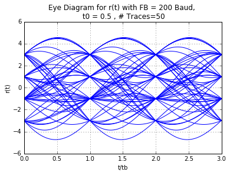

```python
showeye(rt, Fs, FB, NTd, dispparms)
```

# To plot the spectrum and eye-diagram of pamsig401.wav and pamsig402.wav

# For pamsig401.wav

```python
%run wavfun.py
rt,fs = wavread("pamsig401.wav")
```

```python
%run showfun.py
```

```python
tt = arange(len(rt))/fs
ff_lim = [-2000,2000,-60]
```

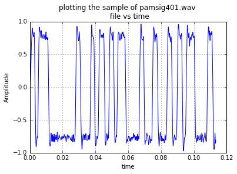

```python
# Plot the signal vs time
plot(tt[0:5000],rt[0:5000])
title('plotting the sample of pamsig401.wav \n file vs time')
xlabel('time')
ylabel('Amplitude')
grid()
show()
```

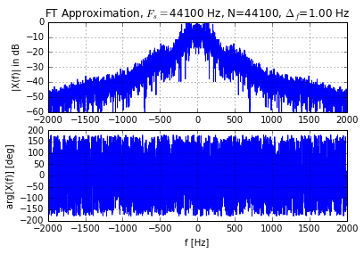

```python
showft(tt, rt, ff_lim)   # finding the spectrum of pamsig401.wav
```

# To find the bit_rate, we will square the rt function and will try to plot the power spectrum. The distance of peak will give the bit rate.

```python
rt_squared = pow(rt,2)
```

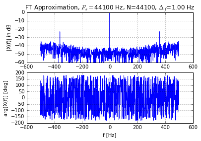

```python
ff_lim = [-500,500,-60]
showft(tt, rt_squared, ff_lim)
```

```python
FB = 360
```

# From the above plot, we find the bit rate is approximately to 360 Hz for pamsig401.wav. Also, from the time-domain plot above, we observe the basic pulse used to be rectangular in this signal.

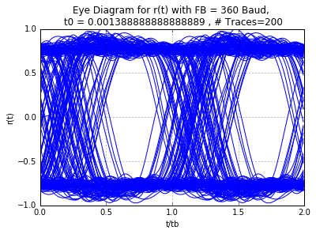

```python
showeye(rt, fs, FB, NTd=200, dispparms=[0.5/FB, 2, -1,1])
```

# From the above plot of eye-diagram, we observe that the two level of signalling is done.

# For pamsig402.wav

```python
rt,fs = wavread("pamsig402.wav")
```

```python
tt = arange(len(rt))/fs
ff_lim = [-500,500,-60]
```

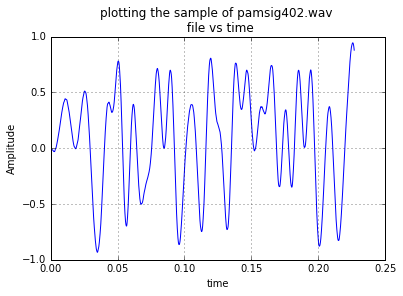

```python
# Plot the signal vs time
plot(tt[0:10000],rt[0:10000])
title('plotting the sample of pamsig402.wav \n file vs time')
xlabel('time')
ylabel('Amplitude')
grid()
show()
```

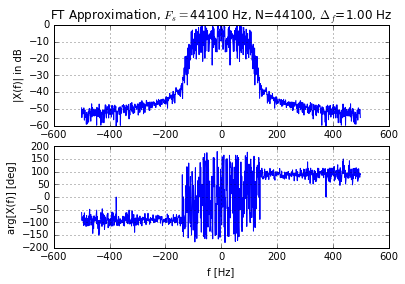

```python
showft(tt, rt, ff_lim)   # finding the spectrum of pamsig401.wav
```